# PHD - Progress update 14/10/2015

Fauzy Bin Che Yayah

October 14, 2015

- Why use Bayesian Net ?
1. To look for the root cause - the dataset is in factor type which is status not a number.
2. To find out the probabilistic relationship between the symptom error code and the resolution

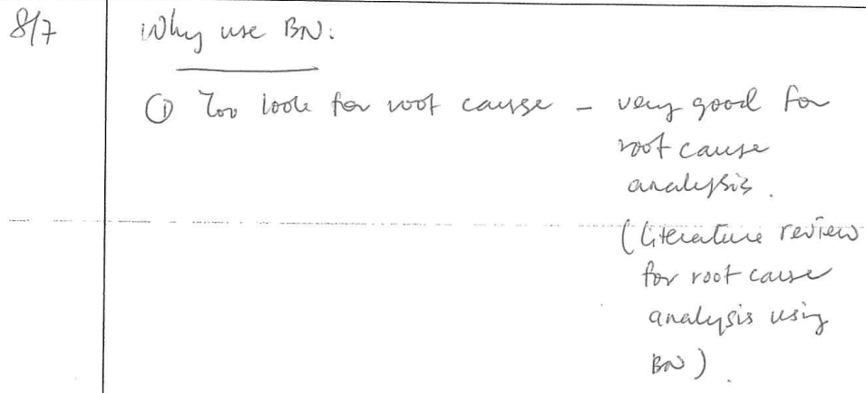

[output not shown]

List of literature review regarding Bayesian Net :-

1.A real-life application of multi-agent systems for fault diagnosis in the provision of an Internet business service

2.A Bayesian Network approach to diagnosing the root cause of failure

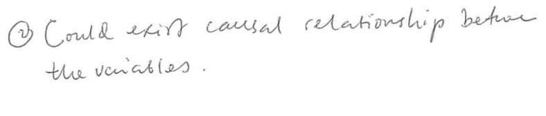

# Process on gathering the dataset

- Acquiring dataset for 100 records, for each zone , randomize , selective year ; ie . 2015
- Rules :-

| Rules | Description |
| --- | --- |
| status = ‘Closed’ | Dataset must be closed for complete information |
| network_tt_id is NULL | Dataset must be not related to Network Trouble Ticket |
| trouble ticket type <> PASSIVE | Trouble Ticket must related to the Active elements such as routers, switches , modem , etc |
| installed_date is NOT NULL | This field must have value |
| created_date is NOT NULL | This field must have value |
| closed_date is NOT NULL | This field must have value |
| closed_date is NOT NULL | This field must have value |
| product is NOT NULL | This field must have value |
| sub_product is NOT NULL | This field must have value |
| length description > 10 | This field is useful for text analysis |
| rand() | Record selection is in random mode |
| zone | Should selective from different zone , sparse |

For sample purpose - selecting dataset from `ZONE KEPONG` for the analysis due to this zone has the **highest records** inside the Trouble Ticket dataset.

- Using Impala for the data retrieval :-

Documentation - https://github.com/piersharding/dplyrimpaladb

- Data processing using DplyrImpalaDb
- Package installation manual below :-

```r
install.packages(c("RJDBC", "devtools", "dplyr"))
devtools::install_github("jwills/dplyrimpaladb")
install.packages("dplyrimpaladb")
```

- Basic notes why choosing Impala.
1. Cloudera ‘Impala’, which is a massively parallel processing (MPP) SQL query engine runs natively in Apache Hadoop
2. Impala’s Place in the Big Data Ecosystem
3. Flexibility for Big Data Workflow
4. High-Performance Analytics

# Connection to Impala

Basic Impala drivers can be downloaded from https://github.com/Mu-Sigma/RImpala/blob/master/impala-jdbc-cdh5.zip

Below is the components required and how to set the class path for the Impala drivers , RJava , RJDBC and dplyr

```r
suppressWarnings(suppressMessages(library("rJava")))
suppressWarnings(suppressMessages(library("RJDBC")))
suppressWarnings(suppressMessages(library("dplyr")))
suppressWarnings(suppressMessages(library("caret")))
suppressWarnings(suppressMessages(library("corrplot")))
suppressWarnings(suppressMessages(library("lazy")))
suppressWarnings(suppressMessages(library("dplyrimpaladb")))
suppressWarnings(suppressMessages(library("rpart")))


.jaddClassPath(c(list.files(paste(getwd(),"/lib",sep = ''),pattern="jar$",full.names=T)))

.jinit(classpath = c(list.files(paste(getwd(),"/lib",sep = ''),pattern="jar$",full.names=T)))

dplyr.jdbc.classpath = c(list.files(paste(getwd(),"/lib",sep = ''),pattern="jar$",full.names=T))

conn <- src_impaladb(dbname='nova', host='10.54.1.151')
```

```
## [1] "here:"
## [1] FALSE
```

- Zone list

```r
result <-  tbl(conn, sql("select zone from nova.nova_trouble_ticket where zone <> 'null' group by zone order by zone limit 1000"))
as.data.frame(result)
```

```
##                          zone
## 1               ZONE AIR ITAM
## 2                  ZONE BANGI
## 3                ZONE BANGSAR
## 4                ZONE BANTING
## 5                   ZONE BATU
## 6             ZONE BATU PAHAT
## 7             ZONE BAYAN BARU
## 8                ZONE BINTULU
## 9         ZONE BUKIT ANGGERIK
## 10        ZONE BUKIT MERTAJAM
## 11            ZONE BUKIT RAJA
## 12           ZONE BUTTERWORTH
## 13             ZONE CYBERJAYA
## 14                ZONE GOMBAK
```

[output cut: 38 more lines]

- Trouble Ticket Data Dictionary

```r
result <-  tbl(conn, sql("select * from nova_trouble_ticket where zone <> 'null' limit 1"))
as.data.frame(apply(as.data.frame(result),2,class))
```

```
##                        apply(as.data.frame(result), 2, class)
## tt_row_id                                           character
## tt_num                                              character
## tt_type                                             character
## tt_sub_type                                         character
## status                                              character
## severity                                            character
## important_message                                   character
## appointment_flag                                    character
## nova_account_name                                   character
## nova_subscriber_num                                 character
## nova_account_num                                    character
## package_row_id                                      character
## created_by                                          character
## category                                            character
## symptom_error_code                                  character
## priority                                            character
## product                                             character
## sub_product                                         character
## package_name                                        character
## network_tt_id                                       character
## swap_order_num                                      character
## cause_category                                      character
## cause_code                                          character
## resolution_code                                     character
## closure_category                                    character
## resolution_team                                     character
## service_affected                                    character
## service_order_num                                   character
## btu_type                                            character
## owner                                               character
## owner_name                                          character
## group_owner                                         character
## owner_position                                      character
## btu_platform                                        character
## dp_location                                         character
## created_date                                        character
## pending_verify_date                                 character
## closed_by                                           character
## closed_date                                         character
```

[output cut: 9 more lines]

```
## timestamp                                           character
## contact_id                                          character
## contact_name                                        character
## contact_office_phone                                character
## contact_mobile_phone                                character
## contact_home_phone                                  character
## contact_email_addr                                  character
## due_date                                            character
## part_num                                            character
## network_layer                                       character
## network_row_id                                      character
## asset_id                                            character
## ptt                                                 character
## zone                                                character
## service_point_id                                    character
```

# Getting the dataset from Impala

Sample dataset - Selection trouble tickets only from **Zone Kepong**. The SQL is define by :-

- Why Kepong zone ?

`Zone Kepong` contains very rich information especially for the textual analysis and also one of the largest composition of the cause code & the resolution code which is good for the supervised learning.

| Rules | Description |
| --- | --- |
| a.status like ‘%Closed%’ | Dataset must be closed for complete information |
| network_tt_id = ‘null’ | Dataset must be not related to Network Trouble Ticket |
| trouble ticket type <> PASSIVE | Trouble Ticket must related to the Active elements such as routers, switches , modem , etc. Excluding for now if related to the `3rd party` causes , `customer behavior` and `Passive` elements |
| installed_date is NOT NULL | This field must have value |
| created_date is NOT NULL | This field must have value |
| closed_date is NOT NULL | This field must have value |
| closed_date is NOT NULL | This field must have value |
| product is NOT NULL | This field must have value |
| sub_product is NOT NULL | This field must have value |
| length description > 10 | This field is useful for text analysis |
| rand() | Record selection is in random mode |
| zone | Should selective from different zone , sparse control |

Generated SQL :-

```r
select * from nova_trouble_ticket a join active_code b on (trim(a.cause_code) = trim(b.cause_code)) join exchange_zone c ON (trim(a.exchange)=trim(c.building_id)) and (b.code <> 'PASSIVE' ) where c.zone_name like '%ZONE KEPONG%' and a.status like '%Closed%'  and length(a.cause_category) > 1  and length(a.created_date) > 6 and length(a.closed_date) > 6 and length(a.installed_date) > 6 and a.package_name not like '%null%' and a.product not like '%null%' and a.sub_product not like '%null%'  and  length(a.description) > 10 and network_tt_id = 'null' order by rand() limit 10000 "
```

# Datset filtering

Removing non-related fields such as trouble ticket key , trouble ticket number , trouble ticket date etc.

```r
conn <- src_impaladb(dbname='nova', host='10.54.1.151')
```

```
## [1] "here:"
## [1] FALSE
```

```r
result <-  tbl(conn, sql("select a.tt_row_id,a.tt_num,a.tt_type,a.tt_sub_type,a.status,a.severity,a.important_message,a.appointment_flag,a.nova_account_name,a.nova_subscriber_num,a.nova_account_num,a.package_row_id,a.created_by,a.category,a.symptom_error_code,a.priority,a.product,a.sub_product,a.package_name,a.network_tt_id,a.swap_order_num,a.cause_category,a.cause_code,a.resolution_code,a.closure_category,a.resolution_team,a.service_affected,a.service_order_num,a.btu_type,a.owner,a.owner_name,a.group_owner,a.owner_position,a.btu_platform,a.dp_location,a.created_date,a.pending_verify_date,a.closed_by,a.closed_date,a.source,a.installed_date,a.description,a.repeat_ticket_count,a.follow_up_ticket_count,a.fdp_device_name,
a.fdp_site_name,a.olt_site_name,a.exchange,a.`timestamp`,a.contact_id,a.contact_name,a.contact_office_phone,a.contact_mobile_phone,a.contact_home_phone,a.contact_email_addr,a.due_date,a.part_num,a.network_layer,a.network_row_id,a.asset_id,a.ptt,a.zone,a.service_point_id , c.zone_name, c.district,c.state, c.region from nova_trouble_ticket a join active_code b on (trim(a.cause_code) = trim(b.cause_code)) join exchange_zone c ON (trim(a.exchange)=trim(c.building_id)) and (b.code <> 'PASSIVE' ) where c.zone_name like '%ZONE KEPONG%' and a.status like '%Closed%' and  length(a.cause_category) > 1 and length(a.created_date) > 6 and length(a.closed_date) > 6 and length(a.installed_date) > 6 and a.package_name not like '%null%' and a.product not like '%null%' and a.sub_product not like '%null%' and  length(a.description) > 10 and a.network_tt_id = 'null' order by rand() limit 100"))

result <- as.data.frame(result)
```

Close the connection from Impala

```r
x <- conn$con
class(x) <- c('JDBCConnection')
dbDisconnect(x)
```

```
## [1] TRUE
```

Save the class as the data.frame

```r
df <- as.data.frame(result)
df$contact_name <- NULL
df$contact_home_phone <- NULL
df$contact_email_addr <- NULL
df$contact_office_phone <- NULL
df$contact_mobile_phone <- NULL
df$`tt_row_id` <- NULL
df$`tt_num` <- NULL
df$tt_type <- NULL
df$`created_date` <- NULL
df$`closed_date` <- NULL
df$`installed_date` <- NULL
df$timestamp <- NULL
df$service_point_id <- NULL
df$contact_id <- NULL
df$owner_position <- NULL
df$tt_sub_type <- NULL
df$severity <- NULL
df$status <- NULL
df$important_message <- NULL
df$network_tt_id <- NULL
df$swap_order_num <- NULL
df$appointment_flag <- NULL
df$nova_account_name <- NULL
df$nova_subscriber_num <- NULL
df$nova_account_num <- NULL
df$repeat_ticket_count <- NULL
df$follow_up_ticket_count <- NULL
df$service_order_num <- NULL
df$source <- NULL
df$owner_name <- NULL
df$description <- NULL
df$due_date <- NULL
df$part_num <- NULL
df$zone <- NULL
df$ptt <- NULL
df$asset_id <- NULL
df$network_layer <- NULL
df$network_row_id <- NULL
df$pending_verify_date <- NULL
df$package_row_id <- NULL
df$priority <- NULL
summary(df)
```

```
##   created_by          category         symptom_error_code
##  Length:100         Length:100         Length:100
##  Class :character   Class :character   Class :character
##  Mode  :character   Mode  :character   Mode  :character
##    product          sub_product        package_name
##  Length:100         Length:100         Length:100
##  Class :character   Class :character   Class :character
##  Mode  :character   Mode  :character   Mode  :character
##  cause_category      cause_code        resolution_code
##  Length:100         Length:100         Length:100
##  Class :character   Class :character   Class :character
##  Mode  :character   Mode  :character   Mode  :character
##  closure_category   resolution_team    service_affected
##  Length:100         Length:100         Length:100
##  Class :character   Class :character   Class :character
##  Mode  :character   Mode  :character   Mode  :character
##    btu_type            owner           group_owner
##  Length:100         Length:100         Length:100
##  Class :character   Class :character   Class :character
##  Mode  :character   Mode  :character   Mode  :character
##  btu_platform       dp_location         closed_by
##  Length:100         Length:100         Length:100
##  Class :character   Class :character   Class :character
##  Mode  :character   Mode  :character   Mode  :character
##  fdp_device_name    fdp_site_name      olt_site_name
##  Length:100         Length:100         Length:100
##  Class :character   Class :character   Class :character
##  Mode  :character   Mode  :character   Mode  :character
##    exchange          zone_name           district
##  Length:100         Length:100         Length:100
##  Class :character   Class :character   Class :character
##  Mode  :character   Mode  :character   Mode  :character
##     state              region
##  Length:100         Length:100
##  Class :character   Class :character
##  Mode  :character   Mode  :character
```

```r
for(i in names(df)){

  num <- as.numeric(as.factor(df[,i]))-1
  df <- cbind(df,num)
  names(df)[names(df)=="num"] <- paste(names(df[i]),"_factor",sep = "")
  print(paste(names(df[i]),"1",sep = ""))
}
```

```
## [1] "created_by1"
## [1] "category1"
## [1] "symptom_error_code1"
## [1] "product1"
## [1] "sub_product1"
## [1] "package_name1"
## [1] "cause_category1"
## [1] "cause_code1"
## [1] "resolution_code1"
## [1] "closure_category1"
## [1] "resolution_team1"
## [1] "service_affected1"
## [1] "btu_type1"
## [1] "owner1"
## [1] "group_owner1"
## [1] "btu_platform1"
## [1] "dp_location1"
## [1] "closed_by1"
## [1] "fdp_device_name1"
## [1] "fdp_site_name1"
## [1] "olt_site_name1"
## [1] "exchange1"
## [1] "zone_name1"
## [1] "district1"
## [1] "state1"
## [1] "region1"
```

```r
df <- df[27:52]
names(df)
```

```
##  [1] "created_by_factor"         "category_factor"
##  [3] "symptom_error_code_factor" "product_factor"
##  [5] "sub_product_factor"        "package_name_factor"
##  [7] "cause_category_factor"     "cause_code_factor"
##  [9] "resolution_code_factor"    "closure_category_factor"
## [11] "resolution_team_factor"    "service_affected_factor"
## [13] "btu_type_factor"           "owner_factor"
## [15] "group_owner_factor"        "btu_platform_factor"
## [17] "dp_location_factor"        "closed_by_factor"
## [19] "fdp_device_name_factor"    "fdp_site_name_factor"
## [21] "olt_site_name_factor"      "exchange_factor"
## [23] "zone_name_factor"          "district_factor"
## [25] "state_factor"              "region_factor"
```

**Remove** the predictors column which might have one unique value which can leads to **zero variance** result

The list below is non-zero variance variables

```r
df <- df[,-nearZeroVar(df)]
names(df)
```

```
##  [1] "created_by_factor"         "category_factor"
##  [3] "symptom_error_code_factor" "product_factor"
##  [5] "sub_product_factor"        "package_name_factor"
##  [7] "cause_category_factor"     "cause_code_factor"
##  [9] "resolution_code_factor"    "closure_category_factor"
## [11] "resolution_team_factor"    "service_affected_factor"
## [13] "btu_type_factor"           "owner_factor"
## [15] "group_owner_factor"        "btu_platform_factor"
## [17] "dp_location_factor"        "closed_by_factor"
## [19] "fdp_device_name_factor"    "fdp_site_name_factor"
## [21] "olt_site_name_factor"      "exchange_factor"
```

Find the correlation between the variables using **Pearson**.

```r
correlations <- cor(df, use="pairwise.complete.obs", method="pearson")
print(correlations)
```

```
##                           created_by_factor category_factor
## created_by_factor               1.000000000    -0.022716809
## category_factor                -0.022716809     1.000000000
## symptom_error_code_factor      -0.116317004     0.055301593
## product_factor                  0.080101570     0.002077136
## sub_product_factor              0.157340914    -0.074369803
## package_name_factor             0.073309656    -0.039877377
## cause_category_factor           0.043650884     0.045077242
## cause_code_factor               0.002586015     0.050826939
## resolution_code_factor         -0.044439987    -0.033322020
## closure_category_factor         0.053472156     0.119308102
## resolution_team_factor          0.041222169     0.166283514
## service_affected_factor        -0.111739689    -0.295735861
## btu_type_factor                -0.063674492     0.027955530
## owner_factor                    0.416953064    -0.015110204
## group_owner_factor             -0.063034950     0.257460573
## btu_platform_factor            -0.030714231    -0.105640527
## dp_location_factor             -0.001965186    -0.004637339
## closed_by_factor                0.416953064    -0.015110204
## fdp_device_name_factor         -0.028583473     0.108131311
## fdp_site_name_factor           -0.028583473     0.108131311
## olt_site_name_factor           -0.010685943     0.082003223
## exchange_factor                -0.012404200     0.059687000
##                           symptom_error_code_factor product_factor
## created_by_factor                      -0.116317004    0.080101570
## category_factor                         0.055301593    0.002077136
## symptom_error_code_factor               1.000000000   -0.105585598
## product_factor                         -0.105585598    1.000000000
## sub_product_factor                     -0.057563223    0.552205017
## package_name_factor                    -0.020498689    0.771767751
## cause_category_factor                   0.122282077    0.272447226
## cause_code_factor                       0.109014624    0.134558684
## resolution_code_factor                  0.017615519    0.322803489
## closure_category_factor                -0.015344723   -0.112354982
## resolution_team_factor                  0.122857005   -0.380702152
## service_affected_factor                -0.261648650    0.291339257
## btu_type_factor                        -0.084263293    0.224198326
## owner_factor                            0.009605624   -0.005273784
## group_owner_factor                     -0.032939587   -0.032222347
## btu_platform_factor                     0.027791022    0.155590378
```

[output cut: 198 more lines]

```
## cause_code_factor            -0.370522912
## resolution_code_factor        0.145791671
## closure_category_factor      -0.005273251
## resolution_team_factor       -0.080950386
## service_affected_factor       0.087832899
## btu_type_factor               0.379739629
## owner_factor                 -0.088227090
## group_owner_factor            0.020402298
## btu_platform_factor           0.390893595
## dp_location_factor           -0.372715466
## closed_by_factor             -0.088227090
## fdp_device_name_factor        0.874999175
## fdp_site_name_factor          0.874999175
## olt_site_name_factor          0.860320990
## exchange_factor               1.000000000
```

Find the **highest correlated** variables.

| Rules | Description |
| --- | --- |
| **- +.70 or higher** | **Very strong relationship** |
| - +.40 to +.69 | Strong positive relationship |
| - +.30 to +.39 | Moderate relationship |
| - +.20 to +.29 | weak relationship |
| - +.01 to +.19 | No or negligible relationship |

```r
# Choose 0.7 Very strong relationship
highlyCorrelated <- findCorrelation(correlations, 0.7 ,verbose = FALSE,names = TRUE)
highlyCorrelated
```

```
## [1] "fdp_device_name_factor" "fdp_site_name_factor"
## [3] "olt_site_name_factor"   "btu_type_factor"
## [5] "btu_platform_factor"    "owner_factor"
## [7] "product_factor"
```

Summary of the correlated variables.

```r
summary(correlations)
```

```
##  created_by_factor   category_factor    symptom_error_code_factor
##  Min.   :-0.116317   Min.   :-0.29574   Min.   :-0.26165
##  1st Qu.:-0.030181   1st Qu.:-0.02082   1st Qu.:-0.10025
##  Median :-0.006326   Median : 0.03652   Median :-0.01792
##  Mean   : 0.079579   Mean   : 0.06708   Mean   : 0.02218
##  3rd Qu.: 0.068350   3rd Qu.: 0.10160   3rd Qu.: 0.04842
##  Max.   : 1.000000   Max.   : 1.00000   Max.   : 1.00000
##  product_factor      sub_product_factor package_name_factor
##  Min.   :-0.380702   Min.   :-0.22982   Min.   :-0.28017
##  1st Qu.:-0.005274   1st Qu.:-0.08390   1st Qu.:-0.07242
##  Median : 0.011846   Median : 0.03779   Median : 0.01612
##  Mean   : 0.142341   Mean   : 0.11096   Mean   : 0.10840
##  3rd Qu.: 0.260385   3rd Qu.: 0.15116   3rd Qu.: 0.15613
##  Max.   : 1.000000   Max.   : 1.00000   Max.   : 1.00000
##  cause_category_factor cause_code_factor  resolution_code_factor
##  Min.   :-0.31966      Min.   :-0.37063   Min.   :-0.48900
##  1st Qu.:-0.03099      1st Qu.:-0.07148   1st Qu.:-0.04166
##  Median : 0.03915      Median : 0.04265   Median : 0.13605
##  Mean   : 0.07643      Mean   : 0.02684   Mean   : 0.11766
##  3rd Qu.: 0.13003      3rd Qu.: 0.13146   3rd Qu.: 0.24992
##  Max.   : 1.00000      Max.   : 1.00000   Max.   : 1.00000
##  closure_category_factor resolution_team_factor service_affected_factor
##  Min.   :-0.154284       Min.   :-0.4890        Min.   :-0.29574
##  1st Qu.:-0.097324       1st Qu.:-0.2251        1st Qu.:-0.10492
##  Median :-0.005994       Median :-0.1216        Median : 0.01855
##  Mean   : 0.017658       Mean   :-0.0312        Mean   : 0.03733
##  3rd Qu.: 0.024702       3rd Qu.: 0.1211        3rd Qu.: 0.07917
##  Max.   : 1.000000       Max.   : 1.0000        Max.   : 1.00000
##  btu_type_factor     owner_factor      group_owner_factor
##  Min.   :-0.77580   Min.   :-0.20081   Min.   :-0.11813
##  1st Qu.:-0.05505   1st Qu.:-0.14442   1st Qu.:-0.03532
##  Median : 0.04402   Median :-0.04330   Median : 0.02091
##  Mean   : 0.16718   Mean   : 0.07095   Mean   : 0.07998
##  3rd Qu.: 0.37610   3rd Qu.: 0.09964   3rd Qu.: 0.09366
##  Max.   : 1.00000   Max.   : 1.00000   Max.   : 1.00000
##  btu_platform_factor dp_location_factor  closed_by_factor
##  Min.   :-0.77372    Min.   :-0.775805   Min.   :-0.20081
##  1st Qu.:-0.05522    1st Qu.:-0.347687   1st Qu.:-0.14442
##  Median : 0.03166    Median :-0.003301   Median :-0.04330
##  Mean   : 0.15574    Mean   :-0.112332   Mean   : 0.07095
##  3rd Qu.: 0.37764    3rd Qu.: 0.107128   3rd Qu.: 0.09964
##  Max.   : 1.00000    Max.   : 1.000000   Max.   : 1.00000
##  fdp_device_name_factor fdp_site_name_factor olt_site_name_factor
##  Min.   :-0.65818       Min.   :-0.65818     Min.   :-0.6245128
##  1st Qu.:-0.12388       1st Qu.:-0.12388     1st Qu.:-0.1350799
##  Median : 0.01827       Median : 0.01827     Median :-0.0004278
##  Mean   : 0.17184       Mean   : 0.17184     Mean   : 0.1679408
##  3rd Qu.: 0.53220       3rd Qu.: 0.53220     3rd Qu.: 0.5398127
##  Max.   : 1.00000       Max.   : 1.00000     Max.   : 1.0000000
##  exchange_factor
##  Min.   :-0.372715
##  1st Qu.:-0.086408
##  Median :-0.001994
##  Mean   : 0.153256
##  3rd Qu.: 0.321253
##  Max.   : 1.000000
```

Plot correlated variables.

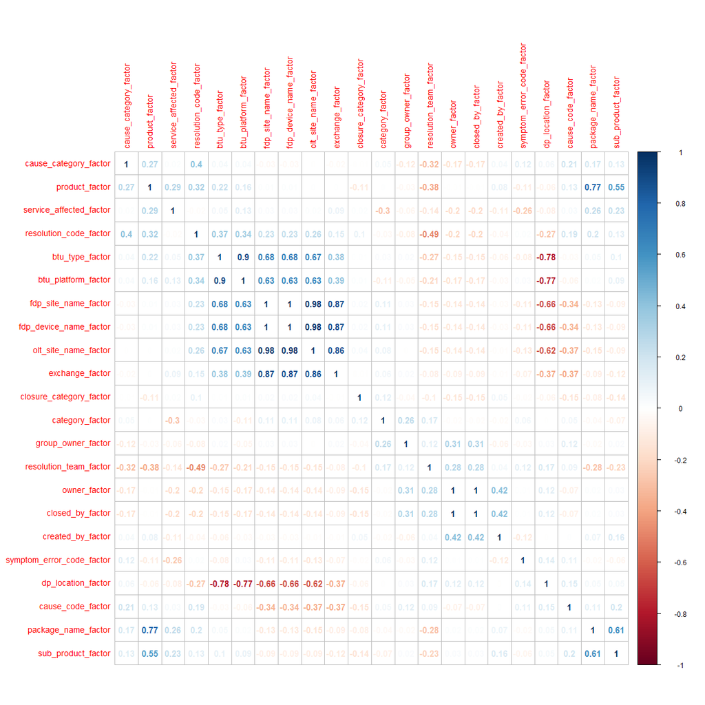

```r
png(height=1200, width=1200, pointsize=15, file="corrplot.png")
corrplot(correlations, method = "number",tl.cex = 0.9 ,addCoef.col="grey", order = "AOE")
dev.off()
```

Feature selection process to confirm which variable does become the independent and **resolution code** is the dependent variable via GBM (Stochastic Gradient Boosting).

List of other available model - http://topepo.github.io/caret/modelList.html

```r
set.seed(777)
suppressWarnings(suppressMessages(library(mlbench)))
control <- trainControl(method = "repeatedcv", number = 10, repeats = 3)
model <-
train(
resolution_code_factor ~ ., data = df, method = "gbm", preProcess = "scale", trControl =
control , verbose = FALSE
)
importance <- varImp(model, scale = TRUE)
print(importance)
```

```
## gbm variable importance
##
##   only 20 most important variables shown (out of 21)
##
##                            Overall
## cause_code_factor         100.0000
## resolution_team_factor     84.3802
## owner_factor               28.7040
## created_by_factor          24.6666
## fdp_device_name_factor     24.5248
## cause_category_factor      21.8225
## service_affected_factor    21.7730
## product_factor              8.3075
## group_owner_factor          8.0461
## dp_location_factor          7.1721
## sub_product_factor          4.7698
## btu_platform_factor         4.6154
## olt_site_name_factor        2.8048
## closure_category_factor     1.7984
## btu_type_factor             0.7352
## package_name_factor         0.7007
## exchange_factor             0.0000
## closed_by_factor            0.0000
## symptom_error_code_factor   0.0000
## fdp_site_name_factor        0.0000
```

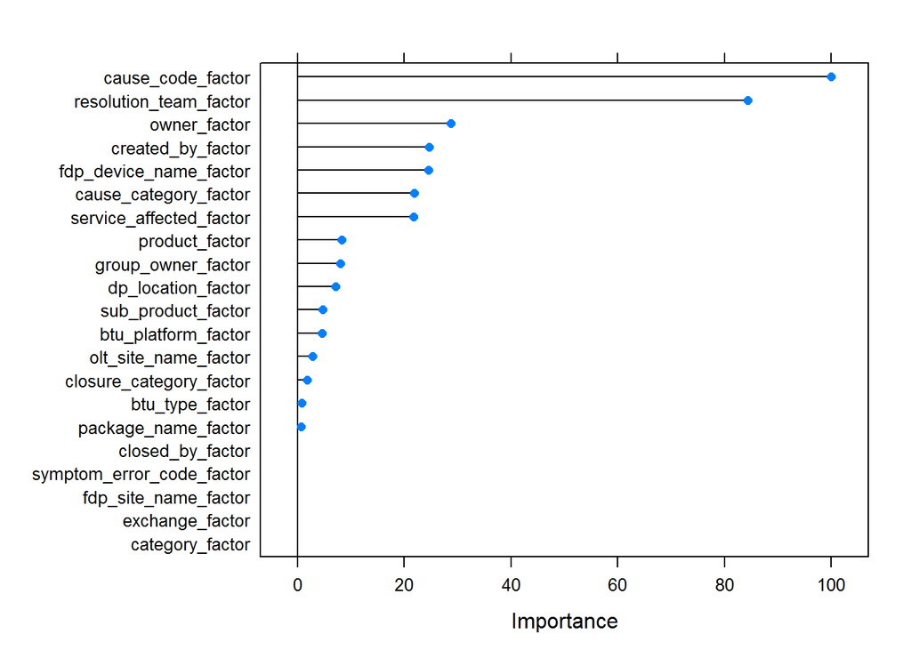

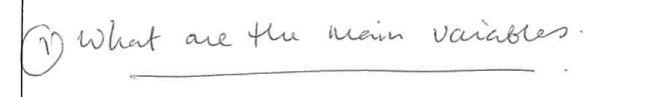

```r
plot(importance)
```

The main variables / factors are :-

as listed from the importance plot

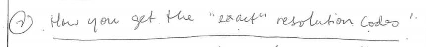

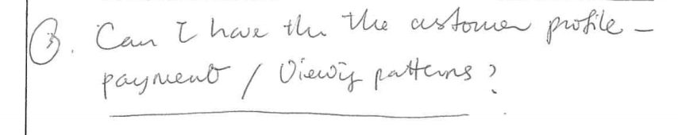

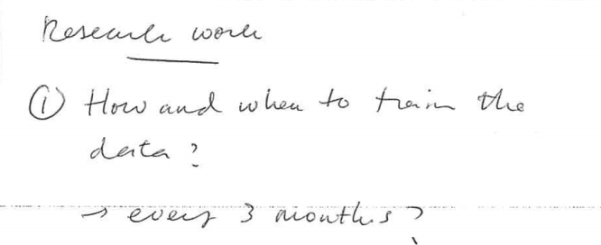

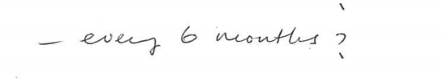

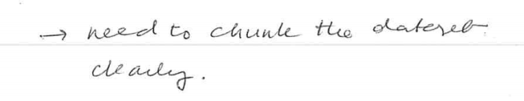

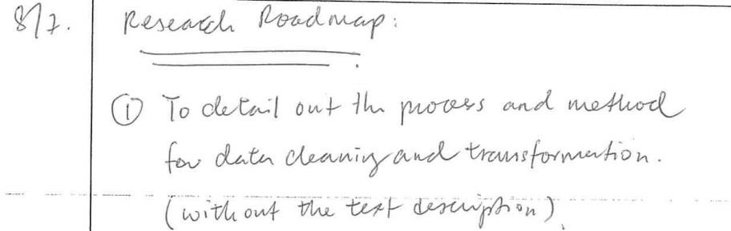